# Exercise 2

Yuting Huang, Jipeng Cheng, Weidi Hou

3/5/2022

# 1 Visualization

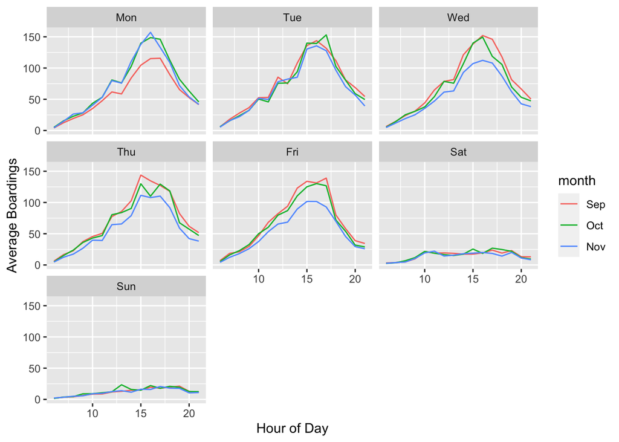

Figure 1.1: Unchanged hour of peak boardings, lower boardings on Mondays in Spetember due to post-holiday blues, and lower boardings on Weds/Thurs/Fri in November because students tend to prepare for the midterm exam at home

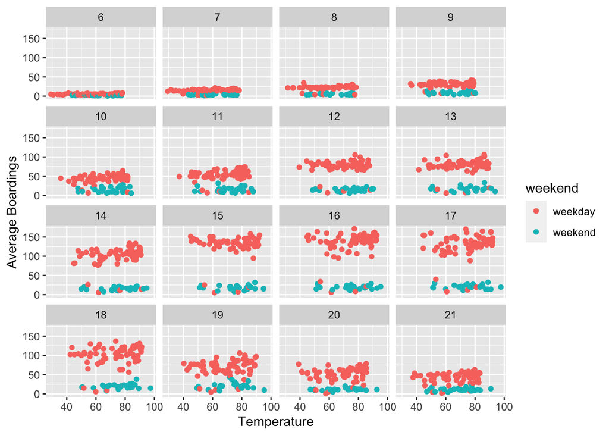

Figure 1.2: Unnoticeable effects of temperature on boardings

# 2 Saratoga house prices

Table 2.1: The RMSEs of Linear Models

| Meiduam Model in Class | New Model 1 | New Model 2 | New Model 3 |
| --- | --- | --- | --- |
| 66685.34 | 77170.16 | 71571.96 | 65424.03 |

The result suggests that New Model 3 is the best linear model for price prediction, since it has the lowest cross-validation RMSE and outperforms the medium model in class. The specification of Model 3 is
$$price=livingarea+centralair+bathrooms+fuel+lotsize+bedrooms+rooms
\\ +livingarea\times centralair+livingarea \times bathrooms+livingarea \times fuel
\\ +livingarea \times rooms+bathrooms \times bedrooms+centralair \times fuel+bathroom \times fuel
\\ +fuel \times lotsize+centralair \times bathrooms+bedrooms \times rooms$$

Table 2.2: The RMSEs of KNN Models

|  | k | err | std_err |
| --- | --- | --- | --- |
| KNN1 | 39 | 77412.93 | 1485.0707 |
| KNN2 | 18 | 68378.36 | 978.0959 |
| KNN3 | 36 | 69113.12 | 1209.1566 |

Given these 2 tables, the linear models seems to do better in achieving lower out of sample RMSE than KNN models do, where the first KNN model uses features in the medium linear models, the second KNN model uses features corresponding to linear model 1&2, and the third model uses features in the linear model 3. Given the out-of-sample performance measured by RMSE, the local taxing authority should choose **linear regression models** with focus on features such as *living areas, having central air-conditioning, fuel, lot size, the total number of rooms, and the number of bathrooms, bedrooms.* The **coefficients** on these features (and some of their interactions) describe how they contribute to the market value of a house and can be informative of predicting the expected market values of them. For example, Table 2.3 reports several coefficients from regression with model 3 and the whole dataset and implies each bathroom values 54570$. The local authority can decompose the market value of a house into the values of these features (captured by these coefficients) and design tax collection from them.

Table 2.3: The Predicted Market Value of House Features (in Part)

|  | Predicted Value |
| --- | --- |
| livingArea | 62.26696 |
| centralAirNo | 53072.86626 |
| bathrooms | 54570.11529 |
| fuelelectric | -9557.23496 |
| fueloil | 67674.35891 |
| lotSize | 2227.68029 |

# 3 Classification and reospective sampling

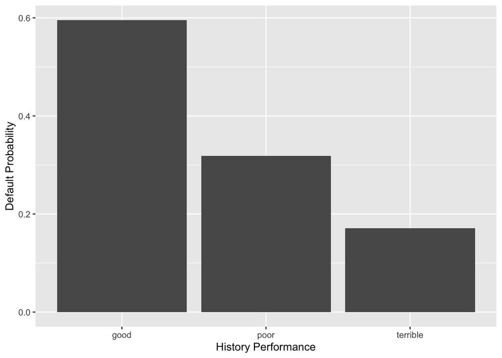

Figure 3.1: Sample Default Probability by History Performance

Table 3.1: History Variable vis-a-vis Predicting Defaults

|  | The partial effects on default probability |
| --- | --- |
| historypoor | -1.11 |
| historyterrible | -1.88 |

The regression result implies that having worse credit is expected to reduce the probability (or more specifically, the odds) of default. The bar plot suggests that the data is constructed in such a way that it contains too many data points of default with good credit history and few default points with bad credit history, which results from the retrospective, “case-control” sampling. The data in inappropriate for building a predictive model of defaults. Because in this data set “default = ture” and “history = good” always occur together, the model would wrongly regard having good credit as an indicator for default. We recommend the bank to change their sampling scheme in order to avoid the artificial selection bias, like using random sampling.

# 4 Children and hotel reservations

## 4.1 Model building

- Feature engineering with LASSO

We use LASSO for feature selection by running LASSO regression and ruling out weak predictors. First, we only consider the main effects of predictors.

Table 4.1: Weak Partial Effects

|  | Partial effects |
| --- | --- |
| mealUndefined | 0 |
| market_segmentComplementary | 0 |
| market_segmentDirect | 0 |
| market_segmentOffline_TA/TO | 0 |
| distribution_channelTA/TO | 0 |
| previous_cancellations | 0 |
| reserved_room_typeL | 0 |
| deposit_typeNon_Refund | 0 |
| deposit_typeRefundable | 0 |

Table 4.2: Top 30 Strongest Predictors and Interactions

| Strong Interaction | Partial Effects | Absolute Values of Partial Effects |
| --- | --- | --- |
| hotelResort_Hotel:reserved_room_typeB | 3.85437584521895 | 3.854376 |
| reserved_room_typeB:assigned_room_typeI | 3.35999361792475 | 3.359994 |
| mealHB:reserved_room_typeF | 3.29065538948407 | 3.290655 |
| reserved_room_typeB:deposit_typeRefundable | -3.20600520381694 | 3.206005 |
| market_segmentComplementary:reserved_room_typeC | 2.70331567289564 | 2.703316 |
| reserved_room_typeD:assigned_room_typeB | 2.67410557646422 | 2.674106 |
| reserved_room_typeL:assigned_room_typeF | 2.54506494236001 | 2.545065 |
| market_segmentOffline_TA/TO:reserved_room_typeH | 2.51874061493095 | 2.518741 |
| mealUndefined:assigned_room_typeD | -2.48027718516247 | 2.480277 |
| hotelResort_Hotel:reserved_room_typeE | -2.44488735028047 | 2.444887 |
| reserved_room_typeB:assigned_room_typeG | 2.29252397050139 | 2.292524 |
| market_segmentOnline_TA:reserved_room_typeB | -2.26370220215917 | 2.263702 |
| reserved_room_typeE | 2.24528538326668 | 2.245285 |
| reserved_room_typeB:assigned_room_typeB | -2.23343707805946 | 2.233437 |
| mealUndefined:reserved_room_typeB | -2.21477616089775 | 2.214776 |
| mealSC:reserved_room_typeF | -2.1835889226233 | 2.183589 |
| market_segmentDirect:reserved_room_typeC | 2.17182130397603 | 2.171821 |
| market_segmentDirect:reserved_room_typeG | -2.13763761106249 | 2.137638 |
| adults:previous_bookings_not_canceled | -2.1159210325544 | 2.115921 |
| mealUndefined:reserved_room_typeG | -2.0800467228209 | 2.080047 |
| mealUndefined:reserved_room_typeE | -1.96330142548346 | 1.963301 |
| market_segmentOnline_TA:reserved_room_typeD | 1.90187523531411 | 1.901875 |
| market_segmentComplementary:reserved_room_typeF | 1.85290684753213 | 1.852907 |
| assigned_room_typeH:required_car_parking_spacesparking | 1.80783756255526 | 1.807838 |
| market_segmentCorporate:assigned_room_typeK | -1.80266989060978 | 1.802670 |
| mealSC:is_repeated_guest | 1.79166997930589 | 1.791670 |
| mealSC:reserved_room_typeC | -1.74587351832503 | 1.745874 |
| reserved_room_typeF | 1.7152475961203 | 1.715248 |
| reserved_room_typeB:assigned_room_typeF | 1.71103971740009 | 1.711040 |
| reserved_room_typeF:assigned_room_typeB | 1.66260757855883 | 1.662608 |

Table 4.3: Interactions That Prevent Converged LASSO

|  | Partial effects |
| --- | --- |
| mealFB:reserved_room_typeB | NA |
| mealUndefined:reserved_room_typeB | NA |
| mealSC:reserved_room_typeH | NA |
| mealUndefined:reserved_room_typeH | NA |
| mealFB:reserved_room_typeL | NA |
| mealHB:reserved_room_typeL | NA |
| mealSC:reserved_room_typeL | NA |
| mealUndefined:reserved_room_typeL | NA |
| reserved_room_typeH:assigned_room_typeB | NA |
| reserved_room_typeL:assigned_room_typeB | NA |
| reserved_room_typeB:assigned_room_typeC | NA |
| reserved_room_typeF:assigned_room_typeC | NA |
| reserved_room_typeG:assigned_room_typeC | NA |
| reserved_room_typeH:assigned_room_typeC | NA |
| reserved_room_typeL:assigned_room_typeC | NA |
| reserved_room_typeF:assigned_room_typeD | NA |
| reserved_room_typeG:assigned_room_typeD | NA |
| reserved_room_typeL:assigned_room_typeD | NA |
| reserved_room_typeH:assigned_room_typeE | NA |
| reserved_room_typeL:assigned_room_typeE | NA |
| reserved_room_typeB:assigned_room_typeF | NA |
| reserved_room_typeH:assigned_room_typeF | NA |
| reserved_room_typeL:assigned_room_typeF | NA |
| reserved_room_typeL:assigned_room_typeG | NA |
| reserved_room_typeB:assigned_room_typeH | NA |
| reserved_room_typeH:assigned_room_typeH | NA |
| reserved_room_typeL:assigned_room_typeH | NA |
| reserved_room_typeB:assigned_room_typeI | NA |
| reserved_room_typeH:assigned_room_typeI | NA |
| reserved_room_typeL:assigned_room_typeI | NA |
| reserved_room_typeC:assigned_room_typeK | NA |
| reserved_room_typeH:assigned_room_typeK | NA |
| reserved_room_typeL:assigned_room_typeK | NA |
| hotelResort_Hotel:reserved_room_typeH | NA |
| hotelResort_Hotel:reserved_room_typeL | NA |
| market_segmentOnline_TA:reserved_room_typeB | NA |
| market_segmentOnline_TA:reserved_room_typeC | NA |
| market_segmentOnline_TA:reserved_room_typeF | NA |
| market_segmentOnline_TA:reserved_room_typeG | NA |
| market_segmentComplementary:reserved_room_typeH | NA |
| market_segmentCorporate:reserved_room_typeH | NA |
| market_segmentGroups:reserved_room_typeH | NA |
| market_segmentOffline_TA/TO:reserved_room_typeH | NA |
| market_segmentOnline_TA:reserved_room_typeH | NA |
| market_segmentComplementary:reserved_room_typeL | NA |
| market_segmentCorporate:reserved_room_typeL | NA |
| market_segmentDirect:reserved_room_typeL | NA |
| market_segmentGroups:reserved_room_typeL | NA |
| market_segmentOffline_TA/TO:reserved_room_typeL | NA |
| market_segmentOnline_TA:reserved_room_typeL | NA |
| market_segmentOnline_TA:customer_typeGroup | NA |
| market_segmentOnline_TA:customer_typeTransient-Party | NA |

Finally, we rule out all the variables and interactions with `NA` according to Table 4.3 since the algorithm does not converge. The selected model adds `hotel:reserved_room_type`, `meal:is_repeated_guest`, `adults:previous_bookings_not_canceled`, `meal:previous_bookings_not_canceled`, `market_segment:customer_type`, `is_repeated_guest:assigned_room_type`, `assigned_room_type:required_car_parking_spaces` as interactions.

- Out-of-sample performance comparison

  Table 4.4: Out-of-sample Performance Evaulation

  |  | Deviance | TPR | FPR | FDR |
  | --- | --- | --- | --- | --- |
  | Baseline 1 | 3289.528 | 0 | 0 | NaN |
  | Baseline 2 | 2363.56 | 0.339 | 0.012 | 0.297 |
  | Best | 2322.647 | 0.371 | 0.013 | 0.286 |

  Table 4.4 shows that our best model outperforms the other 2 baseline models.

## 4.2 Model validation: step 1

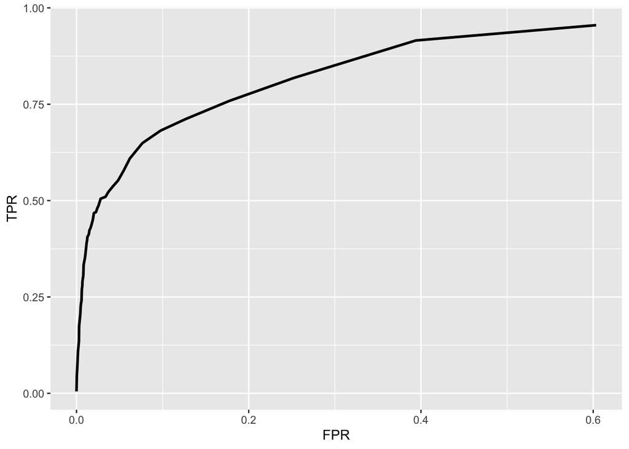

Figure 4.1: ROC Curve

Besides, Figure 4.2 may help us select $t$ if necessary.

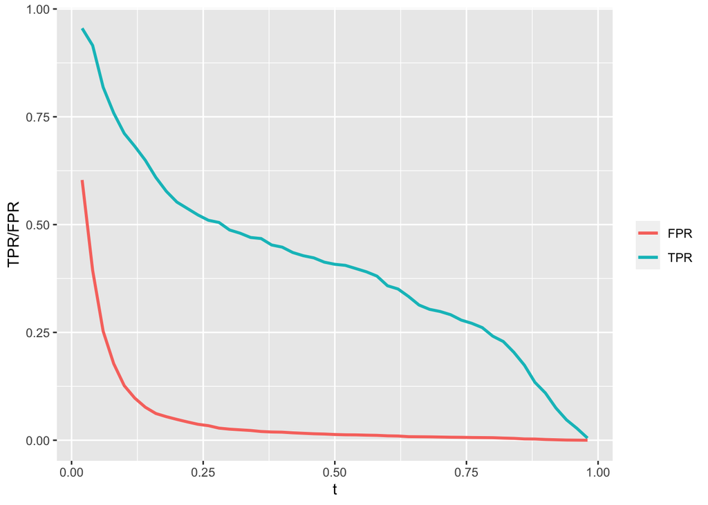

Figure 4.2: TPR/FPR vs. t

## 4.3 Model validation: step 2

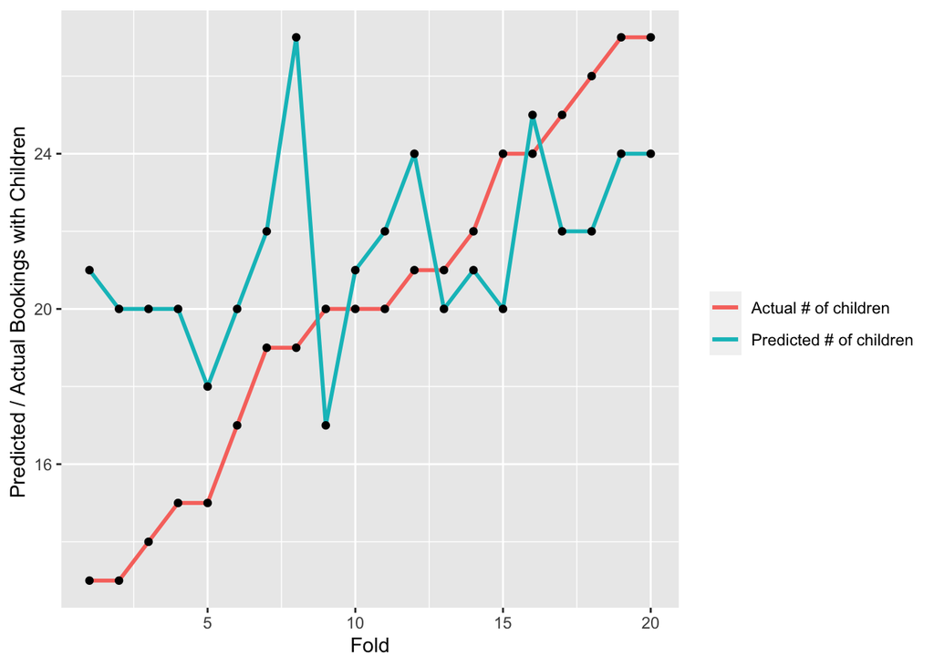

Figure 4.3: Number of Bookings with Children for Each Fold